# Math_118_HW2

Jackson Evans

10/7/2021

```r
library("ggplot2")
library(tidyverse)
library(dplyr)
library(stringr)
library('babynames')
library(plyr)
```

1. According to this data set, what are the top 10 most common baby names for US babies, and how many babies have been born with each of these 10 names?

```r
babynames%>%
  group_by(name)%>%
  summarize(sum=sum(n))%>%
  arrange(desc(sum))%>% #arranging in descending order
  head(10)
```

```
##         sum
## 1 348120517
```

2. Construct a graph showing the number of US births for each of the years since 1880. Using this graph, interpret the relationship between time and the number of US births.

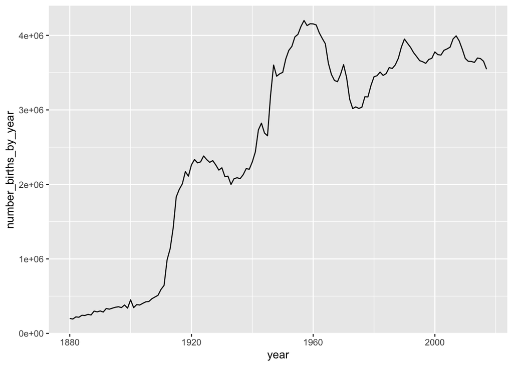

```r
babynames%>%
  group_by(year)%>%
  dplyr::summarize(number_births_by_year=sum(n))%>%
  ggplot()+
  geom_line(aes(x=year, y=number_births_by_year))
```

We see an exponential growth rate between 1880-1920 then another growth around 1940. These likely represent post WW1 and WW2 booms. Based on the graph we can say that the number of births in the US has generally increased over time, but may be approaching an equilibrium.

3. Compare the number of births in the year 2000 based on this data set with the number of births in the year 2000 claimed by the US government. Compare these values - should they be equal?

```r
summary_table<-babynames%>%
  group_by(year)%>%
  dplyr::summarize(number_births_by_year=sum(n))%>%
  filter(year==2000)
```

Based on our data set there were 3,778,079 births in the US in 2000. From the CDC (https://www.cdc.gov/nchs/data/nvsr/nvsr50/nvsr50_05.pdf) the US had 4,058,814 births in 2000. This is clearly a significant difference in data. Over 200,000 births is marginal. This may be due to a few reasons. Based on the way the babynames data was collected, it may only have data for babies named right at the hospital and not account for children given names later. Additionally, when sorting the data frame’s rows by n (number of occurences), we can see that the table only included baby named with 5 or greater occurrences. Therefore the 200,000+ missing values may be babies with names appearing less than 5 times.

4. Identify the two longest names given to at least 1000 US babies.

```r
babynames%>%
  group_by(name)%>%
  filter(n>=1000)%>%
  mutate(name_length=str_length(name))%>%
  dplyr::summarize(name_length, name)%>%
  arrange(desc(name_length))%>% #arranging in descending order
  distinct()%>%
  head(2)
```

```
## # A tibble: 2 × 2
## # Groups:   name [2]
##   name        name_length
##   <chr>             <int>
## 1 Christopher          11
## 2 Maximiliano          11
```

5. Construct a graph of the average length of newborn babies’ names over time. Interpret your findings.

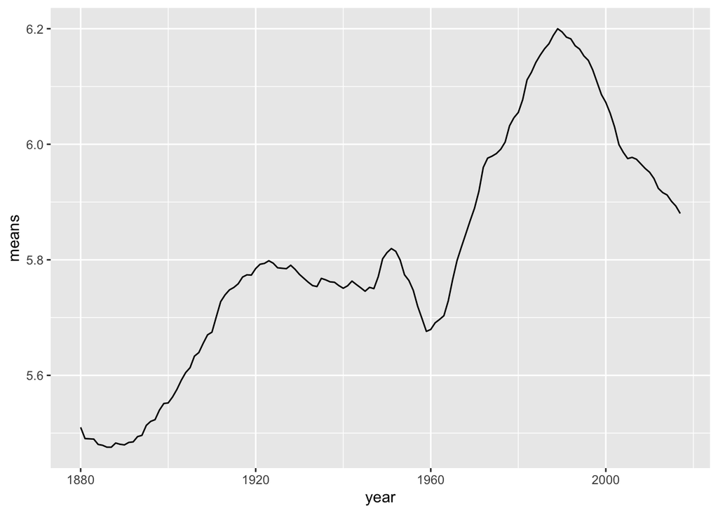

```r
babynames%>%
  mutate(name_length=str_length(name))%>%
  group_by(year)%>%
  dplyr::summarize(means=sum((name_length)*n)/sum(n)) %>%
  ggplot()+
  geom_line(aes(x=year, y=means))
```

The average length of US baby names has generally increased over time since 1880. There seems to be a downward trend from an all-time peak of 6.2 in 1989. More births may represent greater diversity in names given, and to increase the amount of names given it makes sense to keep adding letters.

6. Construct a graph showing the relationship between vowel usage in babies’ names over time

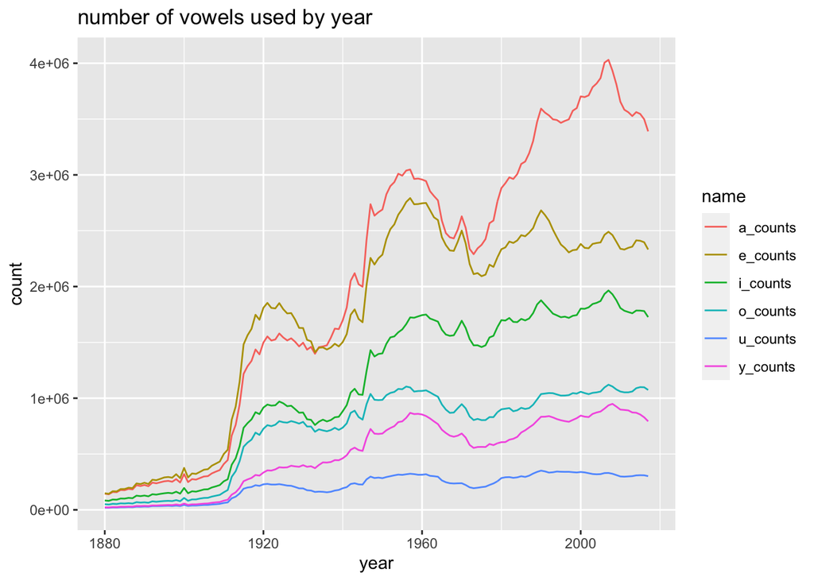

```r
babynames%>%
  mutate(a_vo=str_count(name,'a|A')*n)%>%
  mutate(e_vo=str_count(name,'e|E')*n)%>%
  mutate(i_vo=str_count(name,'i|I')*n)%>%
  mutate(o_vo=str_count(name,'o|O')*n)%>%
  mutate(u_vo=str_count(name,'u|U')*n)%>%
  mutate(y_vo=str_count(name,'y|Y')*n)%>%
  group_by(year)%>%
  dplyr::summarize(a_counts=sum(a_vo), e_counts=sum(e_vo), i_counts=sum(i_vo), o_counts=sum(o_vo), u_counts=sum(u_vo), y_counts=sum(y_vo))%>%
  pivot_longer(!year)%>%

  ggplot(aes(x=year, y=value, color=name))+
  geom_line()+

  labs(x="year", y="count", title="number of vowels used by year")
```

Although y is not always a vowel, we will include it here anyways. This graph, however, still is dependent on the number of births in a given year. Let’ts try to control for that and remove it.

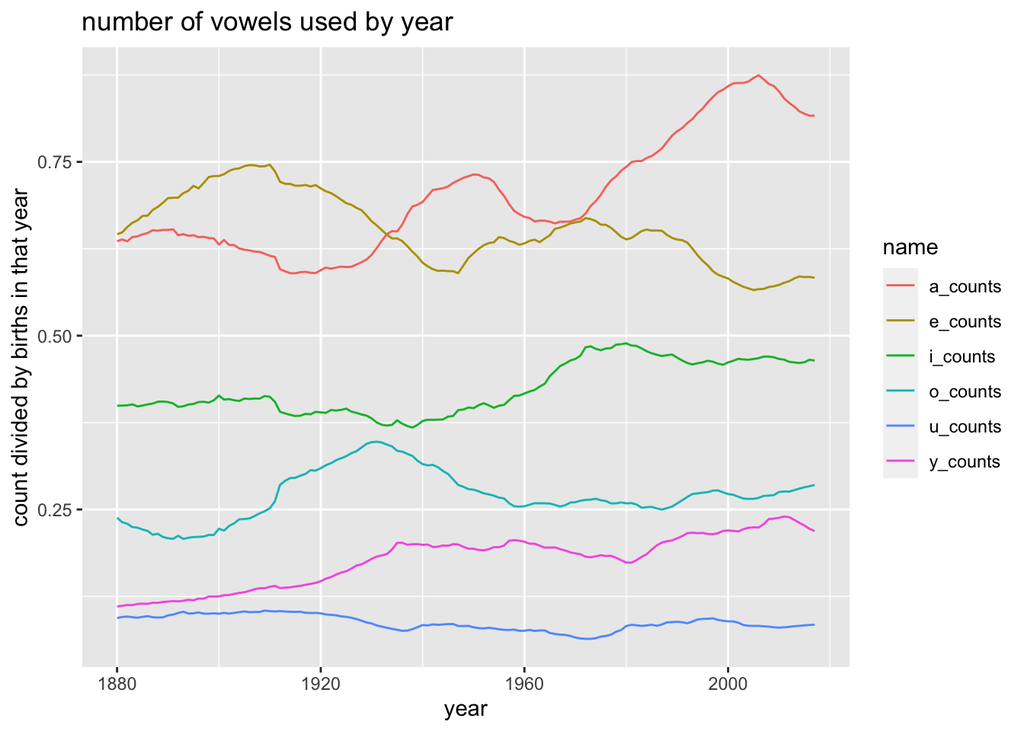

```r
births_per_year<-babynames%>%
  group_by(year)%>%
  dplyr::summarize(number_births_by_year=sum(n))

babynames%>%
  mutate(births_in_year=births_per_year[year-1879,2])%>%
  mutate(a_vo=str_count(name,'a')*n/births_in_year)%>%
  mutate(e_vo=str_count(name,'e')*n/births_in_year)%>%
  mutate(i_vo=str_count(name,'i')*n/births_in_year)%>%
  mutate(o_vo=str_count(name,'o')*n/births_in_year)%>%
  mutate(u_vo=str_count(name,'u')*n/births_in_year)%>%
  mutate(y_vo=str_count(name,'y')*n/births_in_year)%>%
  group_by(year)%>%
  dplyr::summarize(a_counts=sum(a_vo), e_counts=sum(e_vo), i_counts=sum(i_vo), o_counts=sum(o_vo), u_counts=sum(u_vo), y_counts=sum(y_vo))%>%
  pivot_longer(!year)%>%
  ggplot(aes(x=year, y=value, color=name))+
  geom_line()+
  labs(x="year", y="count divided by births in that year", title="number of vowels used by year")
```

By eliminating the year variable, we can more easily see trends within the vowels. A and E seem to trade off in usage historically but A has been more dominant since around 1970. The rest of the vowels don’t seem to overlap at all, with I being the next most common, then O, then Y followed by U. Again, though, y is only sometimes a vowel.

7. Create a graphic that tells a story about the changes in maleness/femaleness of certain names from 1880 to 2017. Use geom_text().

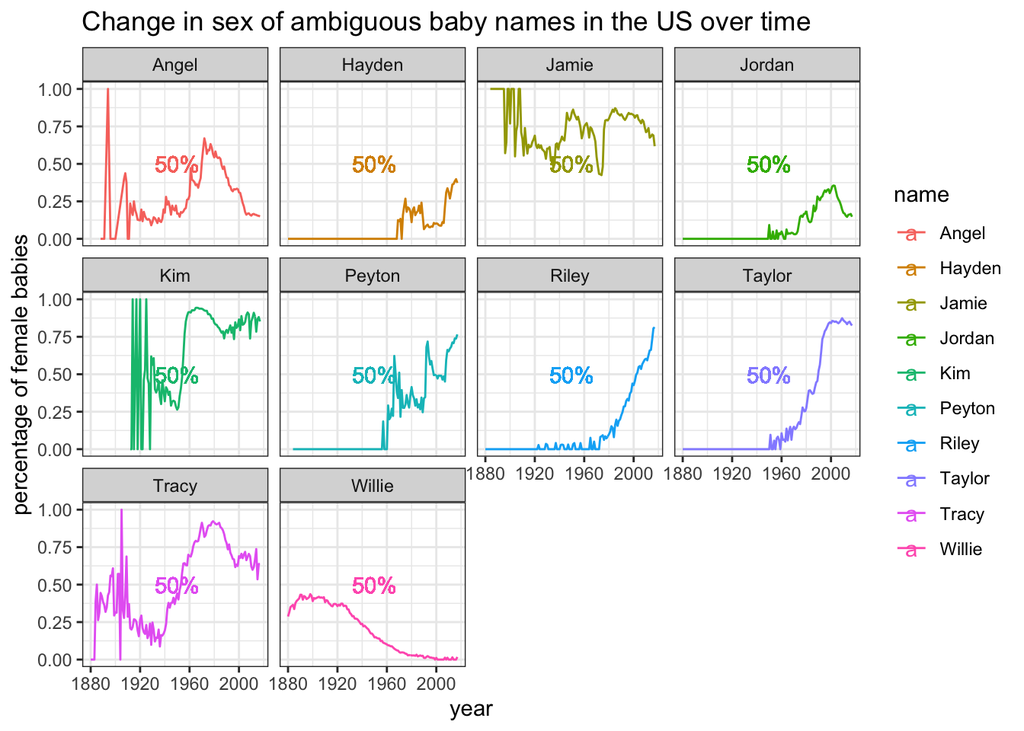

```r
babies<-babynames%>%
  mutate(n_f=case_when(sex=="F"~1*n,
                       sex=='M'~0))%>%
  mutate(n_m=case_when(sex=="M"~1*n,
                       sex=='F'~0))%>%
  group_by(year)

combined<-ddply(babies, .(year, name), numcolwise(sum))
filtered_combined<-combined%>%
  mutate(f_percent=n_f/(n_f+n_m))%>%
  filter(f_percent>=.3 & f_percent<=.7)

ten_names<-filtered_combined[order(filtered_combined$n, decreasing=TRUE),]%>%
  dplyr::summarize(name)%>%
  distinct()%>%
  head(10) #now we have top 10 names of gender ambiguous baby names

fifties<-combined%>%
  filter(year==1950)%>%
  filter(name %in% ten_names$name) %>%
  mutate(f_percent=n_f/(n_f+n_m))

combined%>%
  filter(name %in% ten_names$name) %>%
  mutate(f_percent=n_f/(n_f+n_m))%>%
  group_by(year)%>%
  ggplot(aes(x=year, y=f_percent, color=name))+
  geom_line()+
  facet_wrap(~name)+
  labs(x="year", y="percentage of female babies", title="Change in sex of ambiguous baby names in the US over time")+
  #geom_text(data=fifties ,aes(label = name, y=f_percent+.18),x = 1990)+
  geom_text(aes(label="50%",y=.5), x = 1950)+
  theme_bw()
```